# Homework 1

Araks Karapetyan

28.09.2018

## Read the dataset movies3.csv into R

```r
movies <- read.csv("movies3.csv")
```

## The variable gross_adjusted is showing gross box office of the movie adjusted by inflation. The variable budget_adjusted shows the budget of the movie adjusted by inflation

Write a code that will make variables gross_adjusted and budget_adjusted in 1000 USD. Dont create new variable, just overwrite the old ones. (1 point)

```r
gross_adjusted <- movies$gross_adjusted / 1000
gross_adjusted
```

```
##    [1]   14142.117   29451.448   87570.655   86365.946   39077.724
##    [6]    2978.040  102193.707   35199.809   35808.613  174037.519
##   [11]   17459.687   23491.305    9682.513   92674.514  429084.300
##   [16]   17762.727   91925.253    3650.918    2869.608   51990.999
##   [21]  113870.301   13067.764   28864.799  112601.542  111207.783
##   [26]   49515.160   32736.528  192395.377  159540.518  242199.080
##   [31]  158286.819  205525.969  223910.027   41435.535   20539.152
##   [36]     126.544  202221.467   89296.503  212916.662   85398.660
##   [41]   84023.093    1406.912   27600.133    7143.568  107528.620
##   [46]  149213.383    4703.825    1169.092   75464.824    3715.516
##   [51]      23.246    7342.146     127.051   29081.483   17031.995
##   [56]   55743.790   22013.752  167354.588   44744.091   39219.406
##   [61]   16649.891   65252.672   67528.501    6733.183    2040.038
##   [66]   11732.706   16091.370   22272.159   76920.631   62617.470
##   [71]   89728.968    5896.698   13555.653   14892.519    7842.301
```

[output cut: 568 more lines]

```r
budget_adjusted <- movies$budget_adjusted / 1000
budget_adjusted
```

```
##    [1]  42555.556  51065.177  87177.413  26964.263  76858.659   7519.018
##    [7]  42704.949  81581.157  27323.725  97747.239  20565.963  54376.911
##   [13]  41005.204  26936.264  13921.623  13076.612  65657.143  24730.528
##   [19]   4729.764  10380.942 102463.969   1708.153  22482.298  89929.193
##   [25]  79694.198  68553.210 109193.241  95377.432 174354.825 207082.995
##   [31] 181792.031 171383.025 106759.582 104200.810  16785.391   1215.873
##   [37] 176157.914 160143.558 199920.157  76600.000   3790.515   6660.870
##   [43]  78290.360  11387.689 115778.677  27336.803   8538.664  37595.092
##   [49]  24654.738   6212.490  62124.899   2248.230   4392.832  32691.530
##   [55]  44139.256 156691.495  31142.827 250122.449  30076.074  15531.225
##   [61]  38928.534  17736.614  22482.298   8277.086   1215.873  39989.372
##   [67]  59366.221  21800.556 157831.703  25195.888  48011.858   4270.383
##   [73]   3416.869  17138.302  10354.150  21351.916  15531.225  31628.387
##   [79]  18238.095  21794.353  62283.456  18659.654  17138.302  21351.916
##   [85]  99642.276  42704.949  71173.055 142346.109  28462.214  39847.099
```

[output cut: 471 more lines]

What is the minimum for box office ? What is the minimum for budget ? (1 point)

```r
gross_min <- min(gross_adjusted)
gross_min
```

```
## [1] 0.973
```

```r
budget_min <- min(budget_adjusted)
budget_min
```

```
## [1] 0.29
```

The variable genre_first is showing which genre was mentioned first on the movies imdb webpage

How many Action movies are there? How many comedies ? (2 point)

```r
table(movies$genre_first)[c(1, 5)]
```

```
##
## Action Comedy
##    721    844
```

Create a new dataframe with the most popular geners. Take thos movies only, whose genre appear in the dataframe more than 100 times.(3 points)

Hint Suppose you want to subset the mtcars dataset in a way that will have only cars who has 6 or 8 cylinder. One way to go with it is the following: df <- mtcars[mtcars$cyl == 6 | mtcars$cyl ==8,]

However the most efficient way will be: df <- mtcars[mtcars$cyl %in% c(6, 8),]

```r
table(movies$genre_first)
```

```
##
##      Action   Adventure   Animation   Biography      Comedy       Crime
##         721         281          35         135         844         199
## Documentary       Drama      Family     Fantasy      Horror     Musical
##          25         485           3          26         128           2
##     Mystery     Romance      Sci-Fi    Thriller     Western
##          16           2           7           1           2
```

```r
new_df <- movies[movies$genre_first %in% c("Action", "Adventure", "Biography", "Comedy", "Crime", "Drama", "Horror"), ]
new_df
```

|  | title | genre_first | year | duration | gross_adjusted | budget_adjusted | gross | budget | cast_facebook_likes | reviews | index | Rated | Genre | Director | Writer | Actors | Plot | Language | Country | Awards | Metascore | imdbRating | imdbVotes | Production | DVD | Release | Release_Month | Release_Day | Release_year | … |
| --- | --- | --- | --- | --- | --- | --- | --- | --- | --- | --- | --- | --- | --- | --- | --- | --- | --- | --- | --- | --- | --- | --- | --- | --- | --- | --- | --- | --- | --- | --- |
| 1 | Zoom | Action | 2006 | 83 | 14142117 | 42555556 | 11631245 | 35000000 | 5022 | 176 | 1.215873 | PG | Action, Adventure, Comedy | Peter Hewitt | Adam Rifkin (screenplay), David Berenbaum (screenplay), Adam Rifkin (screen story), Jason Lethcoe (novel) | Tim Allen, Courteney Cox, Chevy Chase, Spencer Breslin | Former superhero Jack is called back to work to transform an unlikely group of ragtag kids into superheroes at a private academy. | English | USA | 4 wins & 8 nominations. | 26 | 4.3 | 16367 | Sony Pictures Entertainment | 9/2/2007 | 8/11/2006 | 8 | 11 | 2006 | … |
| 2 | Zoolander 2 | Comedy | 2016 | 102 | 29451448 | 51065177 | 28837115 | 50000000 | 24107 | 376 | 1.021304 | PG-13 | Comedy | Ben Stiller | Justin Theroux, Ben Stiller, Nicholas Stoller, John Hamburg, Drake Sather (character Derek Zoolander), Ben Stiller (character Derek Zoolander) | Justin Bieber, Jon Daly, Penélope Cruz, Ben Stiller | Derek and Hansel are lured into modelling again, in Rome, where they find themselves the target of a sinister conspiracy. | English, Italian, Spanish | USA | 7 wins & 17 nominations. | 34 | 4.7 | 53943 | Paramount Pictures | 5/24/2016 | 2/12/2016 | 2 | 12 | 2016 | … |
| 3 | Zookeeper | Comedy | 2011 | 102 | 87570655 | 87177413 | 80360866 | 80000000 | 5392 | 305 | 1.089718 | PG | Comedy, Family, Romance | Frank Coraci | Nick Bakay (screenplay), Rock Reuben (screenplay), Kevin James (screenplay), Jay Scherick (screenplay), David Ronn (screenplay), Jay Scherick (story), David Ronn (story) | Kevin James, Rosario Dawson, Leslie Bibb, Ken Jeong | A group of zoo animals decide to break their code of silence in order to help their lovable zoo keeper find love -- without opting to leave his current job for something more illustrious. | English | USA | 1 win & 2 nominations. | 30 | 5.2 | 49098 | Columbia Pictures | 10/11/2011 | 7/8/2011 | 7 | 8 | 2011 | … |
| 4 | Zombieland | Adventure | 2009 | 88 | 86365946 | 26964263 | 75590286 | 23600000 | 28011 | 998 | 1.142553 | R | Adventure, Comedy, Horror | Ruben Fleischer | Rhett Reese, Paul Wernick | Jesse Eisenberg, Woody Harrelson, Emma Stone, Abigail Breslin | A shy student trying to reach his family in Ohio, a gun-toting tough guy trying to find the last Twinkie, and a pair of sisters trying to get to an amusement park join forces to travel across a zombie… | English | USA | 9 wins & 28 nominations. | 73 | 7.7 | 426786 | Sony/Columbia Pictures | 2/2/2010 | 10/2/2009 | 10 | 2 | 2009 | … |
| 5 | Zodiac | Crime | 2007 | 162 | 39077724 | 76858659 | 33048353 | 65000000 | 36928 | 966 | 1.182441 | R | Crime, Drama, History | David Fincher | James Vanderbilt (screenplay), Robert Graysmith (book) | Jake Gyllenhaal, Mark Ruffalo, Anthony Edwards, Robert Downey Jr. | In the late 1960s/early 1970s, a San Francisco cartoonist becomes an amateur detective obsessed with tracking down the Zodiac Killer, an unidentified individual who terrorizes Northern California with… | English | USA | 2 wins & 67 nominations. | 78 | 7.7 | 353948 | Paramount Pictures | 7/24/2007 | 3/2/2007 | 3 | 2 | 2007 | … |
| 6 | Zero Effect | Comedy | 1998 | 116 | 2978040 | 7519018 | 1980338 | 5000000 | 1209 | 232 | 1.503804 | R | Comedy, Crime, Drama | Jake Kasdan | Jake Kasdan | Bill Pullman, Ben Stiller, Ryan O'Neal, Kim Dickens | The world's greatest detective Daryl Zero aided by his associate Steve Arlo investigates a complex and mysterious case of blackmail and missing keys for shady tycoon Gregory Stark who is less than for… | English | USA | 1 nomination. | NA | 7.0 | 12912 | Warner Home Video | 7/7/1998 | 1/30/1998 | 1 | 30 | 1998 | … |
| 7 | Zero Dark Thirty | Drama | 2012 | 157 | 102193707 | 42704949 | 95720716 | 40000000 | 2759 | 1198 | 1.067624 | R | Drama, Thriller | Kathryn Bigelow | Mark Boal | Jason Clarke, Reda Kateb, Jessica Chastain, Kyle Chandler | A chronicle of the decade-long hunt for al-Qaeda terrorist leader Osama bin Laden after the September 2001 attacks, and his death at the hands of the Navy S.E.A.L.s Team 6 in May 2011. | English, Arabic | USA | Won 1 Oscar. Another 87 wins & 171 nominations. | 95 | 7.4 | 235120 | Columbia Pictures | 3/19/2013 | 1/11/2013 | 1 | 11 | 2013 | … |
| 8 | Zathura: A Space Adventure | Action | 2005 | 101 | 35199809 | 81581157 | 28045540 | 65000000 | 32232 | 338 | 1.255095 | PG | Action, Adventure, Comedy | Jon Favreau | Chris Van Allsburg (book), David Koepp (screenplay), John Kamps (screenplay) | Jonah Bobo, Josh Hutcherson, Dax Shepard, Kristen Stewart | Two young brothers are drawn into an intergalactic adventure when their house is hurled through the depths of space by the magical board game they are playing. | English | USA | 2 wins & 3 nominations. | 67 | 6.1 | 76203 | Sony Pictures | 2/14/2006 | 11/11/2005 | 11 | 11 | 2005 | … |
| 9 | Zack and Miri Make a Porno | Comedy | 2008 | 101 | 35808613 | 27323725 | 31452765 | 24000000 | 638 | 490 | 1.138489 | R | Comedy, Romance | Kevin Smith | Kevin Smith | Elizabeth Banks, Seth Rogen, Craig Robinson, Gerry Bednob | Lifelong platonic friends Zack and Miri look to solve their respective cash-flow problems by making an adult film together. As the cameras roll, however, the duo begin to sense that they may have more… | English | USA | 2 wins & 4 nominations. | 56 | 6.6 | 158735 | The Weinstein Company | 2/3/2009 | 10/31/2008 | 10 | 31 | 2008 | … |
| 10 | You've Got Mail | Comedy | 1998 | 119 | 174037519 | 97747239 | 115731542 | 65000000 | 17768 | 709 | 1.503804 | PG | Comedy, Drama, Romance | Nora Ephron | Miklós László (play), Nora Ephron (screenplay), Delia Ephron (screenplay) | Tom Hanks, Meg Ryan, Greg Kinnear, Parker Posey | Two business rivals who despise each other in real life unwittingly fall in love over the Internet. | English | USA | Nominated for 1 Golden Globe. Another 5 wins & 7 nominations. | 57 | 6.6 | 167217 | Warner Bros. Pictures | 5/4/1999 | 12/18/1998 | 12 | 18 | 1998 | … |

[output cut: 2783 more lines]

what is the standard deviation of the imdbRating.(2 points) Hint. If you are getting NA after running the function, one reason can be that the variable has NA inside. Look at the help of the function, specifically for the argument na.rm

```r
imdbRating <- new_df$imdbRating
sd(imdbRating, na.rm = TRUE)
```

```
## [1] 1.035619
```

On average, which gener has made the highest box office revenue ? (5 points)

Hint: use function ?aggregate (https://goo.gl/DUyftz) or anything else, but dont give me lenghty code

```r
aggregate <- aggregate(new_df$gross_adjusted, by = list(new_df$genre_first), FUN = mean, na.rm = TRUE)
aggregate
```

| Group.1 | x |
| --- | --- |
| Action | 116323930 |
| Adventure | 126427147 |
| Biography | 72316466 |
| Comedy | 61421028 |
| Crime | 58571121 |
| Drama | 64764868 |
| Horror | 59965089 |

```r
aggregate[order(aggregate$x, decreasing = T), ] [1, ]
```

|  | Group.1 | x |
| --- | --- | --- |
| 2 | Adventure | 126427147 |

Using ggplot construct scatterplot between imdbRating and Metascore. (3 points)

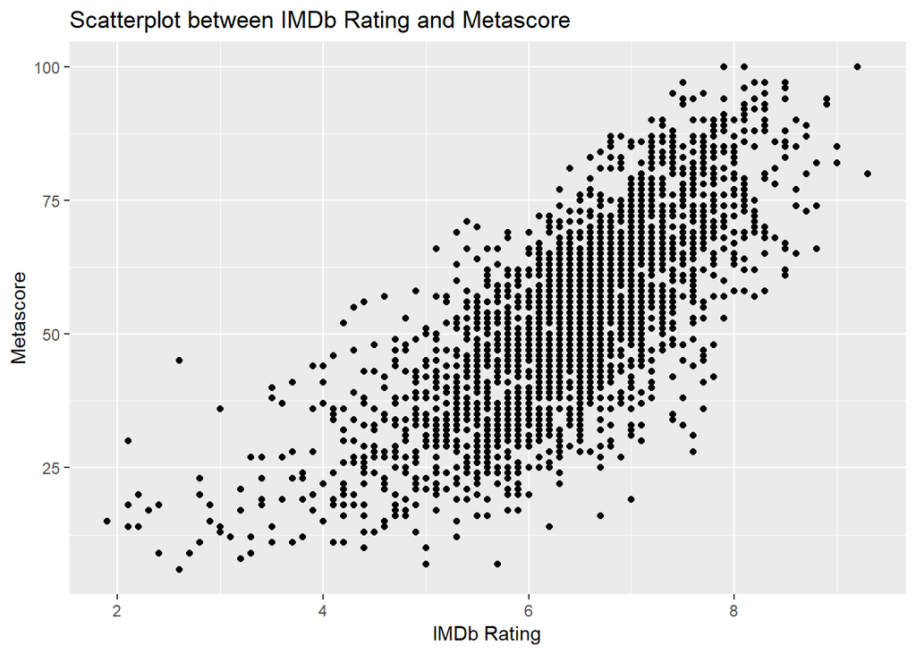

```r
library(ggplot2)
ggplot(data = new_df, aes(x = imdbRating, y = Metascore)) +
  geom_point() +
  ggtitle("Scatterplot between IMDb Rating and Metascore") +
  labs(x = "IMDb Rating", y = "Metascore")
```

Do the same thing for each genre (using facet_grid() or facet_wrap()) (3 points)

[figure not shown]

```r
library(ggplot2)
ggplot(data = new_df, aes(x = imdbRating, y = Metascore)) +
  geom_point() +
  facet_wrap(.~genre_first) +
  labs(x = "IMDb Rating", y = "Metascore") +
  ggtitle("Scatterplot for each genre")
```

Construct histogram for imdbRating for each genre (3 point)

[figure not shown]

```r
ggplot(data = new_df, aes(x = imdbRating)) +
  geom_histogram() +
  facet_wrap(.~genre_first) +
  ggtitle("Histogram for IMDb Rating for each genre") +
  labs(x = "IMDb Rating", y = "Count")
```

Calculate mean, median and sdadard deviation of imdbRating and Metascore for each genre.(4 points)

```r
aggregate(imdbRating~genre_first, new_df, mean)
```

| genre_first | imdbRating |
| --- | --- |
| Action | 6.227645 |
| Adventure | 6.498208 |
| Biography | 7.114925 |
| Comedy | 6.111442 |
| Crime | 6.933838 |
| Drama | 6.743125 |
| Horror | 5.797656 |

```r
aggregate(imdbRating~genre_first, new_df, median)
```

| genre_first | imdbRating |
| --- | --- |
| Action | 6.30 |
| Adventure | 6.60 |
| Biography | 7.20 |
| Comedy | 6.20 |
| Crime | 6.90 |
| Drama | 6.80 |
| Horror | 5.85 |

```r
aggregate(imdbRating~genre_first, new_df, sd)
```

| genre_first | imdbRating |
| --- | --- |
| Action | 1.0211729 |
| Adventure | 1.0883442 |
| Biography | 0.7538879 |
| Comedy | 1.0146364 |
| Crime | 0.8300917 |
| Drama | 0.8989640 |
| Horror | 0.9605170 |

```r
aggregate(Metascore~genre_first, new_df, mean)
```

| genre_first | Metascore |
| --- | --- |
| Action | 48.83566 |
| Adventure | 56.79681 |
| Biography | 65.54331 |
| Comedy | 49.74583 |
| Crime | 59.85000 |
| Drama | 58.00899 |
| Horror | 43.88496 |

```r
aggregate(Metascore~genre_first, new_df, median)
```

| genre_first | Metascore |
| --- | --- |
| Action | 48 |
| Adventure | 58 |
| Biography | 67 |
| Comedy | 49 |
| Crime | 61 |
| Drama | 58 |
| Horror | 40 |

```r
aggregate(Metascore~genre_first, new_df, sd)
```

| genre_first | Metascore |
| --- | --- |
| Action | 16.12233 |
| Adventure | 17.27155 |
| Biography | 14.60309 |
| Comedy | 17.73453 |
| Crime | 16.60836 |
| Drama | 17.78209 |
| Horror | 17.99144 |

Based on the previous 3 questions, describe your findings in one paragraph.(5 poits)

My comments: There is a positive linear reltaionship between IMDb Rating and Metascore on the scatterplot. As we can see from the graph the dots are pretty close to each other which states that the relationship is also quite strong. However, on the scatterplot we still notice some outliers which means that only few people disliked or liked the movies depending on the movie genre. Another thing I noticed is that when the standard deviation is high the mean is low which means low rating was given to the movies. The histograms are mainly left-skewed which I think indicates the fact that more people gave rating to the movies.

Create a binary variable based on the column OscarWon taking the valu 1, if the film got an Oscar and 0 if it does not. You can use ifelse for this.(3 points)

```r
oscar <- ifelse(new_df$OscarWon>0, 1, 0)
oscar
```

```
##    [1] 0 0 0 0 0 0 1 0 0 0 0 0 0 0 0 0 0 0 0 0 0 0 0 0 0 0 0 0 0 0 0 0 0 0
##   [35] 0 0 0 0 0 0 0 1 0 0 1 0 0 0 0 0 0 0 0 0 0 0 0 0 0 0 0 0 0 0 0 0 0 0
##   [69] 0 0 1 0 0 0 0 0 0 0 0 0 0 0 0 0 0 0 0 0 1 0 1 0 0 0 0 0 0 0 0 0 0 0
##  [103] 0 0 0 0 0 0 0 0 0 0 0 0 0 0 0 1 0 0 1 0 0 0 0 0 0 0 0 0 0 0 0 0 0 0
##  [137] 0 0 0 0 0 0 0 0 0 0 0 0 0 0 1 0 0 0 0 0 1 0 0 0 0 0 0 0 0 0 0 0 0 0
##  [171] 0 0 0 0 0 0 0 0 0 0 0 0 0 0 0 0 0 0 0 0 0 0 0 0 0 0 0 0 0 0 0 0 0 0
##  [205] 0 0 1 1 1 0 0 0 0 0 0 1 0 1 0 0 0 0 0 0 1 0 0 0 0 0 0 0 0 0 0 0 0 0
##  [239] 0 0 0 0 0 0 0 0 0 0 0 0 0 1 0 0 0 0 0 0 0 0 0 0 0 0 1 0 1 0 0 0 0 0
##  [273] 0 0 0 0 0 0 0 0 0 0 0 0 0 0 0 0 0 1 0 1 0 0 0 0 0 0 0 0 0 0 0 0 0 0
##  [307] 0 0 0 0 0 0 0 0 0 0 0 0 0 0 0 0 0 1 0 0 0 0 0 0 0 0 0 0 0 1 0 0 1 0
##  [341] 0 0 0 0 0 0 0 0 1 0 0 0 0 0 0 0 0 0 0 0 0 0 0 0 0 0 0 0 0 0 0 0 0 0
##  [375] 0 0 0 0 0 0 1 0 0 0 0 1 1 0 0 0 1 0 0 0 0 0 0 0 0 0 0 0 0 0 0 0 1 0
##  [409] 0 0 0 0 0 0 0 0 0 0 0 0 0 0 0 0 0 0 0 0 0 0 0 0 0 0 0 0 0 0 0 1 0 0
##  [443] 0 0 0 0 0 0 0 0 0 0 1 0 0 0 0 0 0 0 0 0 0 0 0 0 0 0 0 0 1 0 0 0 0 0
##  [477] 0 0 0 0 0 0 0 0 0 0 0 0 0 0 0 0 0 0 0 0 1 1 0 0 0 0 0 0 1 0 0 0 0 0
```

[output cut: 68 more lines]

Write a code to see what genre films have the highest probability of being awarded Oscar(2 points)

```r
prop.table(table(new_df$genre_first, new_df$OscarWon>0), 1)
```

```
##
##                    FALSE       TRUE
##   Action      0.95561720 0.04438280
##   Adventure   0.87188612 0.12811388
##   Animation
##   Biography   0.74074074 0.25925926
##   Comedy      0.96682464 0.03317536
##   Crime       0.88944724 0.11055276
##   Documentary
##   Drama       0.87628866 0.12371134
##   Family
##   Fantasy
##   Horror      0.99218750 0.00781250
##   Musical
##   Mystery
##   Romance
##   Sci-Fi
##   Thriller
##   Western
```

use visualization to illustrate the difference in means of budgets of films winning Oscar with those not winning one.(3 points)

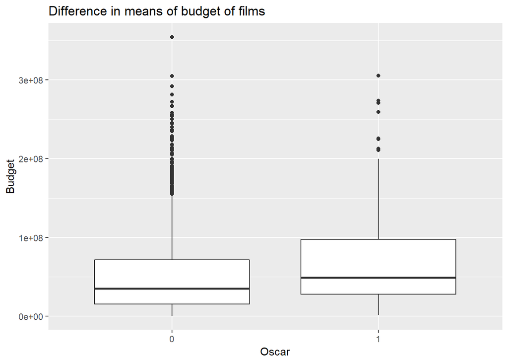

```r
ggplot(new_df, aes(x = as.factor(oscar), y = budget_adjusted)) +
  geom_boxplot() +
  labs(x = "Oscar", y = "Budget") +
  ggtitle("Difference in means of budget of films")
```